# ASA PROJET

Raphaëlle Lebailly, Pierre-Alexandre Quittet, Bastien Clemot, Chloé Pérou

2023-10-05

Lien GitHub du projet : https://github.com/bClemot-Sc/Projet-ASA

# Packages ———————————————-

#### Installation (si nécessaire)

```r
# install.packages("corrplot")
# install.packages("ade4")
# install.packages("lubridate")
# install.packages("car")
# install.packages("lme4")
# install.packages("caret")
```

#### Chargement ———————————————-

```r
library(corrplot)  # Matrice de corrélation
library(ade4)
library(lubridate)  # Convertir données temporelles en secondes
library(car)  # Fonction vif() et anova()
library(lme4)  # Modèle gaussien mixte
library(caret) # Validation croisée
```

# Sujet d’étude : Data butterfly ———————————————-

Etude des effets du génotype, du métabolisme et des conditions environnementales sur les conditions thermiques des papillons en vol.

# Importer les data ———————————————-

Le fichier de données possède 32 variables métaboliques, génotypiques et environementales. Les variables sont les suivantes :

- **ID** : identié du papillon
- **eclosion_day** : jour d’éclosion
- **sex** : sexe
- **FMR_day** : jour de la mesure du taux métabolique pendant le vol
- **age_FMR** : age au temps de la mesure de FMR
- **mass** : masse de l’individu
- **FMR** : taux métabolique en vol estimé avec le CO² total émis pendant 7 minutes de vol dans des conditions de contrôle corrigé par le taux métabolique au repos
- **flight_day** : jour de vol
- **age_flight** : âge au jour de vol
- **sun_flight** : index de soleil [0 = pas de nuage , … ,5 totalement nuageux]
- **wind_flight** : index de vent [0 = pas de vent, …, 5 = très venteux]
- **air_T** : température de l’air pendant le vol
- **dew_flight** : point de rosée
- **humidity_flight** : humidité relative (%)
- **solar_radiation_flight** : radiation solaire pendant le vol
- **flight_duration** : temps de vol
- **disturbed_flight** : nécessité d’aider le papillon à voler ? [YES ; NO]
- **stop_flight** : nécessité d’arrêter le vol du papillon à la fin de l’expérience ? [YES ; NO]
- **takeoff_time** : horaire au décollage
- **takeoff_T_thorax** : température moyenne à la surface du thorax au décollage
- **end_flight_time** : horaire de fin de vol
- **mean_T_flight** : température moyenne à la surface du thorax pendant le vol
- **fln_113** : SNP position 113 du gène fln flightin (lié à la capacité de vol)
- **G6p1d_239** : SNP position 239 du gène G6p1d glucose 6 phosphate 1 déshydrogénase
- **Hsp70_1_206** : Position SNP 206 du gène hsp70_1 heat shock protein 1 (protéine - exprimée en cas de stress thermique)
- **Hsp70_1_134** : SNP position 134 du gène hsp70_1 heat shock protein 1 (protéine - exprimée en cas de stress thermique)
- **Hsp70_3_71** : SNP position 71 du gène hsp70_1 heat shock protein 1 (protéine - exprimée en cas de stress thermique)
- **Hsp70_4_166** : SNP position 166 du gène hsp70_1 heat shock protein 1 (protéine - exprimée en cas de stress thermique)
- **Pgi_105** : SNP position 105 du gène pgi phosphoglucose isomérase lié à plusieurs - composantes de la condition physique en interaction avec la température (voir - ci-dessous)
- **Pgi_1083** : SNP position 1083 du gène pgi phosphoglucose isomérase lié à - plusieurs composantes du fitness en interaction avec la température (voir - ci-dessous)
- **Pgi_331** : La position SNP 331 du gène pgi phosphoglucose isomérase est liée à - plusieurs composantes de l’aptitude à interagir avec la température (voir - ci-dessous).
- **SDHD_149** : Position SNP 149 du gène SDHD complexe succinate déshydrogénase
- **TnT2_100** _ Position SNP 100 du gène TnT2 troponine T

```r
data <- read.table(
  file = "C:/Users/p_a_8/OneDrive/Bureau/M2 MODE/COURS/Semestre 3/ASA/PROJET/ASA_data_projet.txt",
  stringsAsFactors = T,
  header = T,
  na.strings = "NA",
  dec = ",",
  sep = ""
)
```

# Data cleaning ———————————————-

#### — Renomme les variables

On renomme les variables avec les noms ci-dessus (plus courts et explicites).

```r
colnames(data)[1:22] <- c(
  "ID",
  "eclosion_day",
  "sex",
  "FMR_day",
  "age_FMR",
  "mass",
  "FMR",
  "flight_day",
  "age_flight",
  "sun_flight",
  "wind_flight",
  "air_T",
  "dew_flight",
  "humidity_flight",
  "solar_radiation_flight",
  "flight_duration",
  "disturbed_flight",
  "stop_flight",
  "takeoff_time",
  "takeoff_T_thorax",
  "end_flight_time",
  "mean_T_flight"
)
```

#### — Supprime la colonne “ID”

```r
data <- data[, !colnames(data) %in% "ID"]
```

#### — Conversion des variables “heures” en seconde

```r
data$takeoff_time <-  format(as.POSIXct(data$takeoff_time, format = "%H:%M:%S"), format = "%H:%M:%S")
data$end_flight_time <-  format(as.POSIXct(data$end_flight_time, format = "%H:%M:%S"), format = "%H:%M:%S")
```

#### — Extraire les heures, les minutes et les secondes

```r
for (variable_name in c("takeoff_time", "end_flight_time")){

  data[, variable_name] <- hms(data[, variable_name])
  heures <- hour(data[, variable_name])
  minutes <- minute(data[, variable_name])
  secondes <- second(data[, variable_name])

  # Convertir les heures, les minutes et les secondes en secondes
  data[, variable_name] <- heures * 3600 + minutes * 60 + secondes
}
```

#### — Conversion des variables “facteurs”

```r
data$wind_flight <- as.factor(data$wind_flight)
data$sun_flight <- as.factor(data$sun_flight)
data$age_FMR <- as.factor(data$age_FMR)
data$flight_day <- as.factor(data$flight_day)

# On recode les modalités de sexe
data$sex <- ifelse(
    test = data$sex == "FEMALE",
    yes = "F",
    no = "M"
  )

data$sex <- as.factor(data$sex)
```

#### — Identification et visualisation des données manquantes

```r
# Identification des NAs par variables (en %)
data_na <-
  apply(
    X = data,
    MARGIN = 2,
    FUN = function(x) round(sum(is.na(x)) / nrow(data) * 100, 2)
  )
```

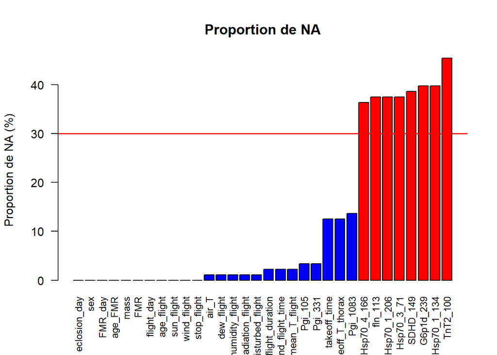

#### — Suppression des données manquantes

On supprime les variables ayant plus de 30% de données manquantes.

```r
#On supprime les variables avec plus de 30% de données manquantes (NA)
data <- data[, !colnames(data) %in% names(data_na[data_na>30])]

#On supprime les individus avec des NAs pour la variable réponse (mean_T_flight)
data <- data[!is.na(data$mean_T_flight),]
```

# VISUALISATION DES DONNEES

Dans cette analyse la variable réponse **y** est **mean_T_flight** représentant la température moyenne du thorax pendant le vol.

#### — Visualisation de la variable mean_T_flight

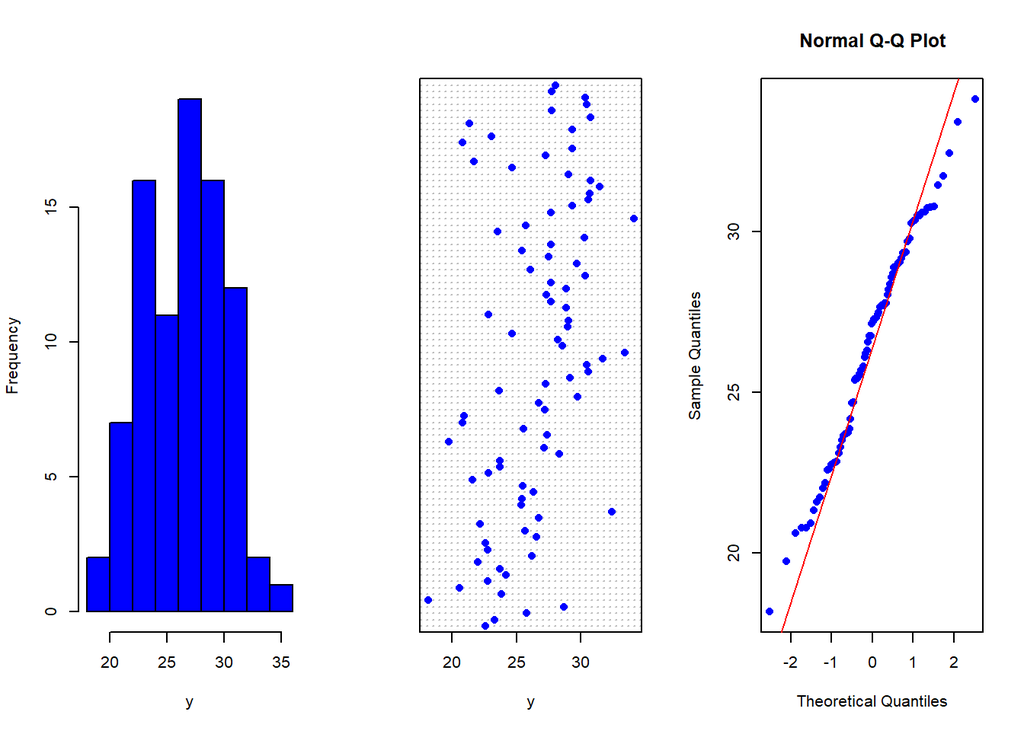

La variable réponse suit une loi normale. Pas d’outliers détectés.

#### — Visualisation des distribution des X

**Facteurs**

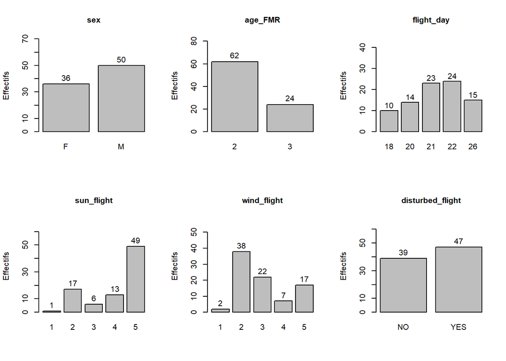

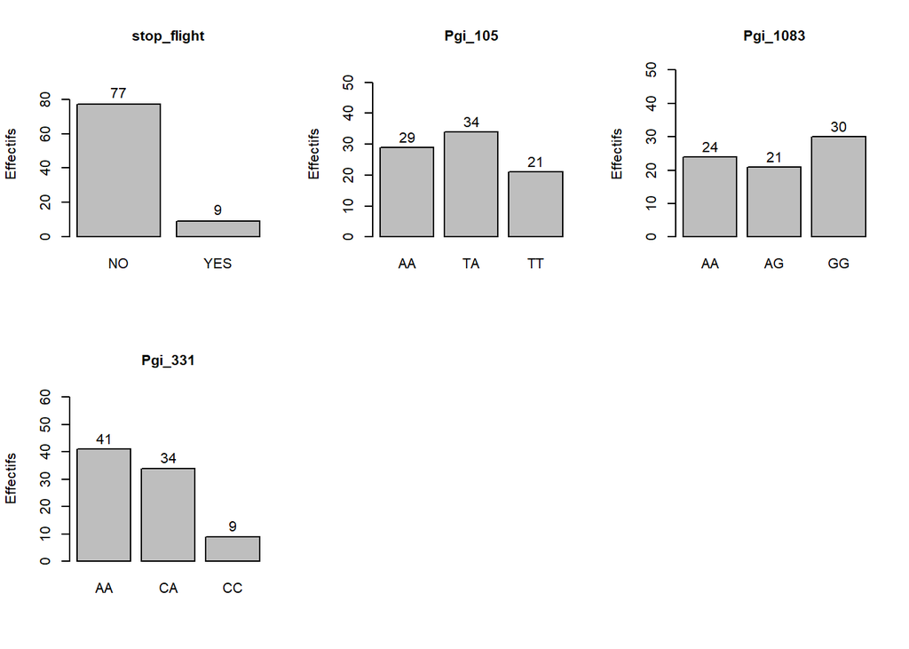

Les variables **sun_flight** et **wind_flight** ont une modalité (“1”) avec respectivement, 1 et 2 réplicats. Ces modalités sont inutilisables pour estimer des paramètres. On créé donc une autre modalité : “<2”.

```r
# Reformatage
# --- Sun_flight
data$sun_flight <- ifelse(
    test = data$sun_flight == 1 | data$sun_flight == 2,
    yes = "<2",
    no = data$sun_flight
  )

# --- Wind_flight
data$wind_flight <- ifelse(
    test = data$wind_flight == 1 | data$wind_flight == 2,
    yes = "<2",
    no = data$wind_flight
  )


# Conversion en facteur
data$sun_flight  <- as.factor(data$sun_flight)
data$wind_flight <- as.factor(data$wind_flight)

# On modifie aussi data_factor
data_factor$sun_flight <- data$sun_flight
data_factor$wind_flight <- data$wind_flight
```

Revisualisation

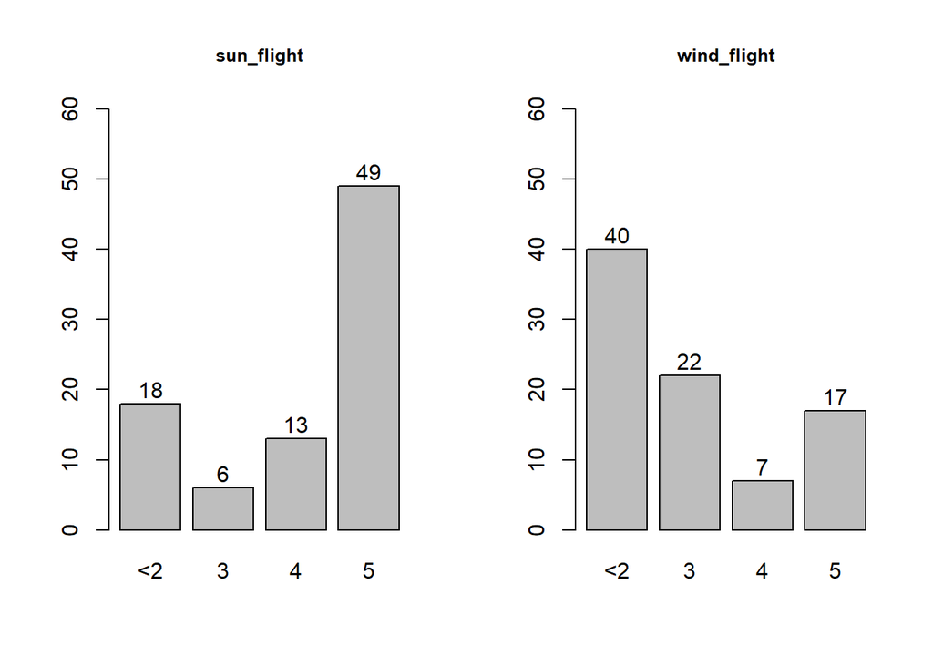

**Covariables**  
On visualise la distribution des variables quantitatives.

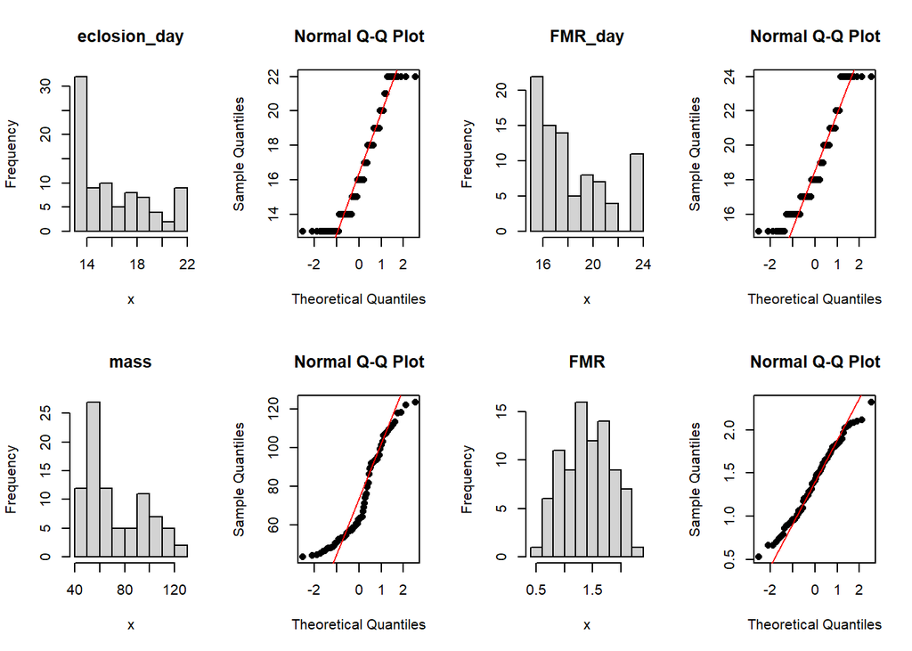

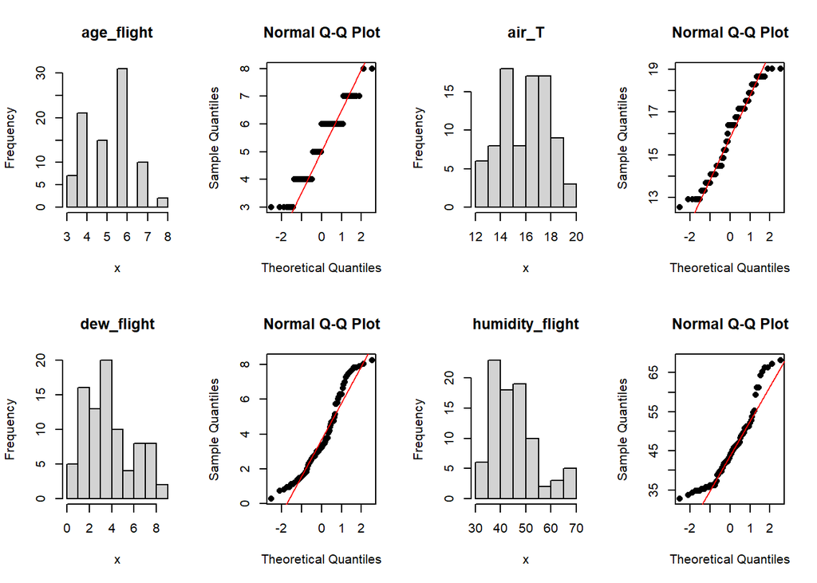

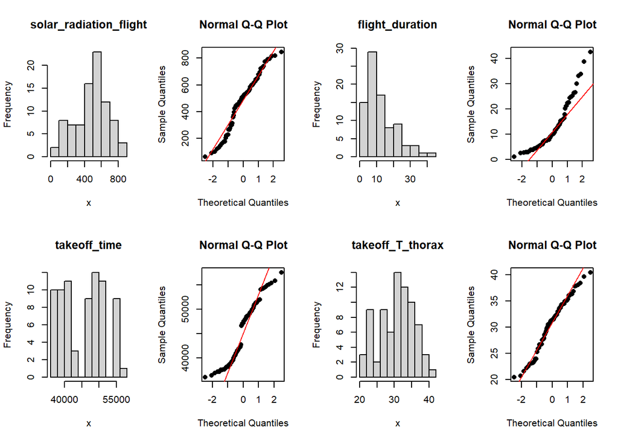

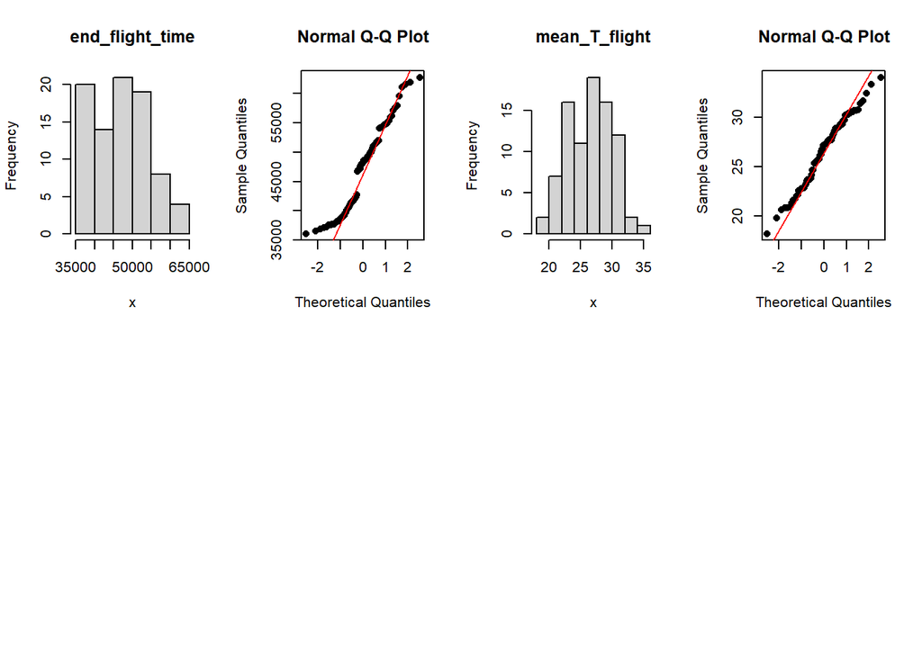

On tente de normaliser les données suivantes qui s’éloignent d’une loi Gaussienne :

- Eclosion day
- FMR_day
- mass
- humidity_flight
- flight_duration
- takeoff_time

On visualise respectivement les variables (1) sans transformation (2) log transformées et (3) racine carrée transformée :

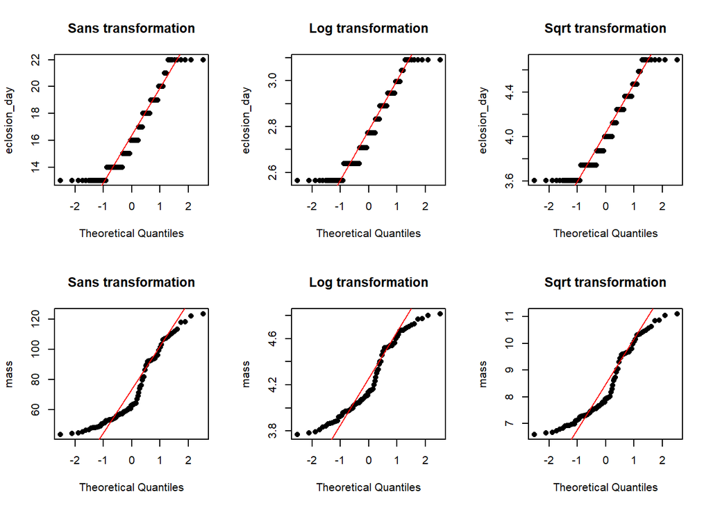

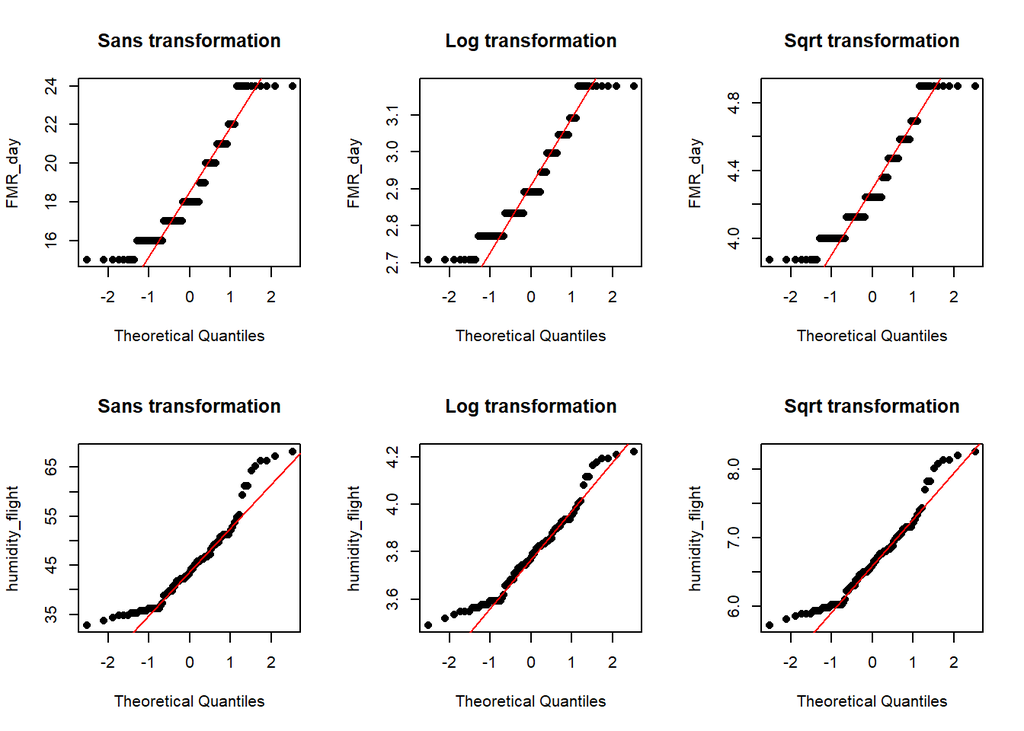

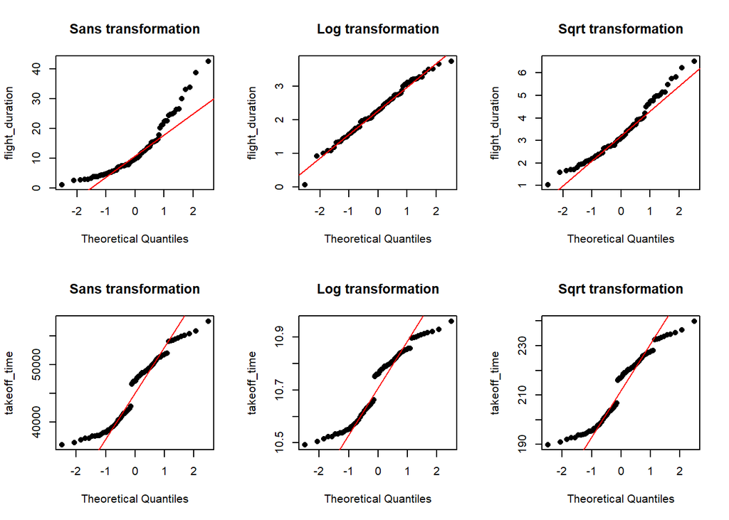

On transorme les variables suivantes avec le logaritme pour ‘normaliser’ la distribution :

- humidity_flight
- flight_duration

#### — Visualisation des distribution mean_T_flight ~ X

**Facteurs** On visualise la distribution de la variable réponse **mean_T_flight** en fonction des variables catégorielles.

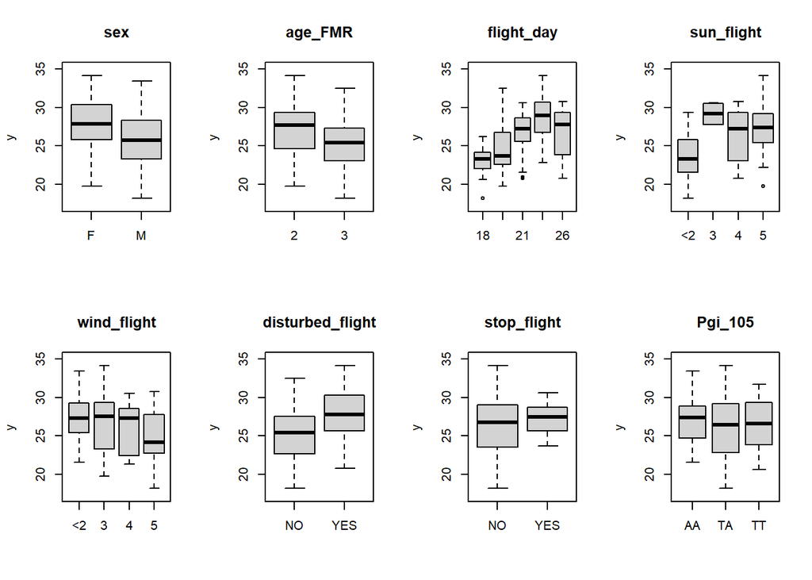

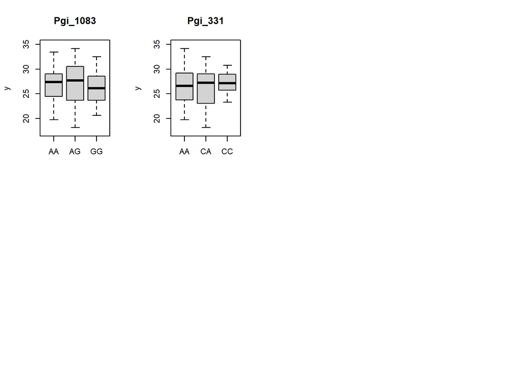

**Covariables**

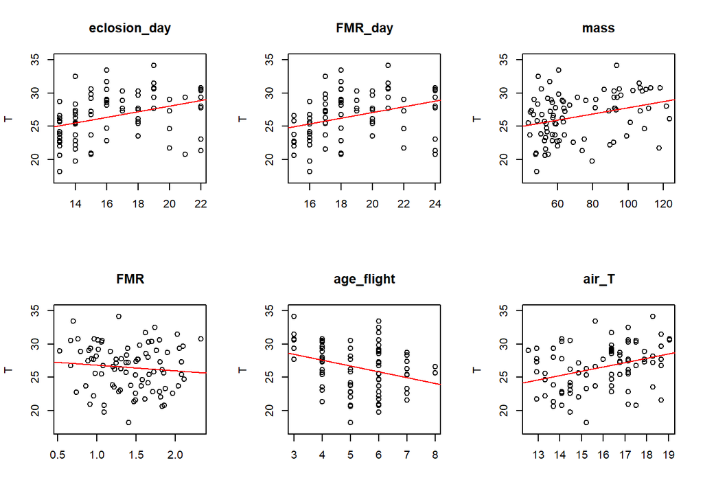

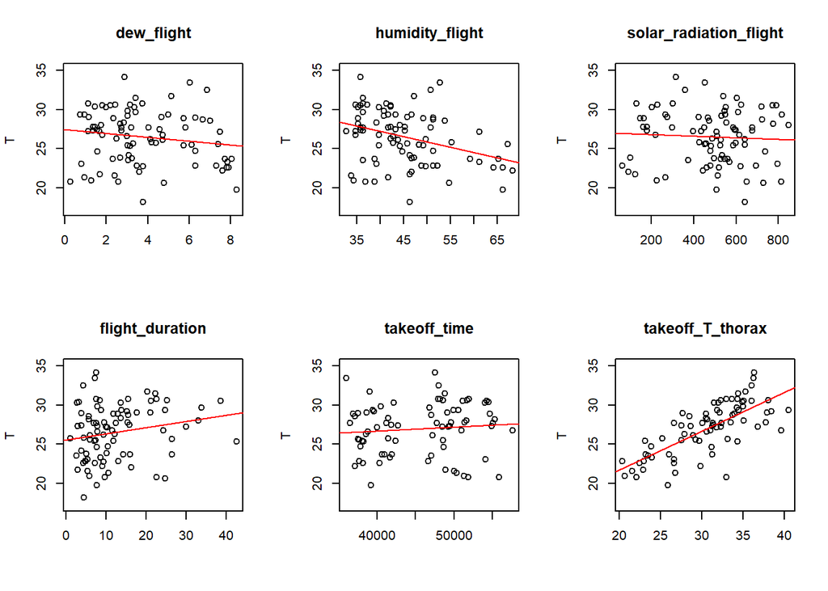

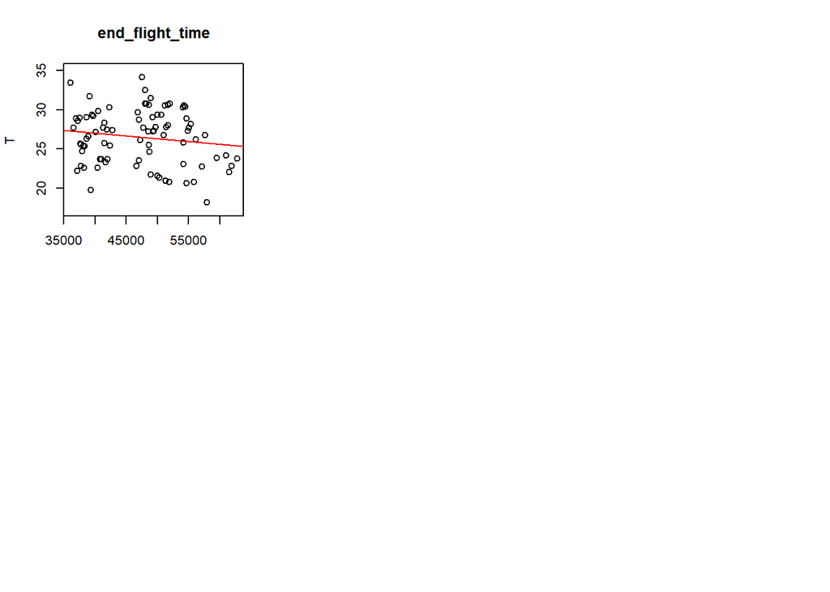

On observe une relation linéaire positive entre **mean_T_flight** et les variables : eclosion_day, FMR_day, mass, air_T, flight_duration et takeoff_T_thorax. A l’inverse, on observe une relation linéaire négative entre **y** et age_flight, dew_flight, humidity_flight. Aucune relation entre **y** et les variables FMR, solar_radiation_flight, takeoff_time et end_flight_time.

# Intéractions entre y ~ facteurs / co-variables

### A) Gène * environnement

#### — Température de l’air et SNP331 (ref : bibliographie)

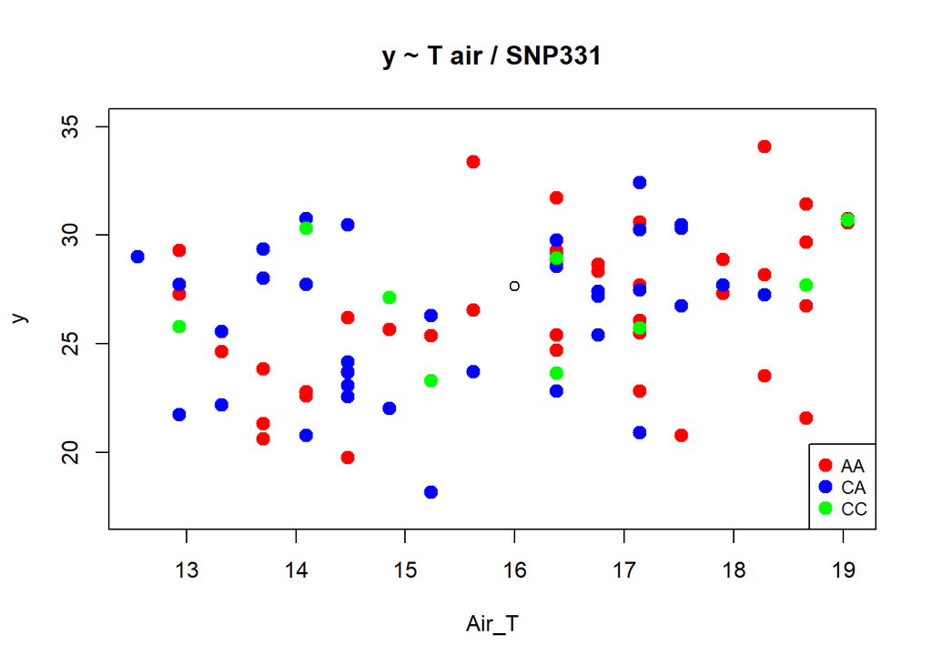

On n’observe pas de pattern clair d’interaction entre la température de l’air et le SNP331 sur la température du vol (tous les groupes [couleurs] de points se chevauchent).

### B) Sexe * variables physiologiques et comportementales

#### — y ~ Masse*sexe

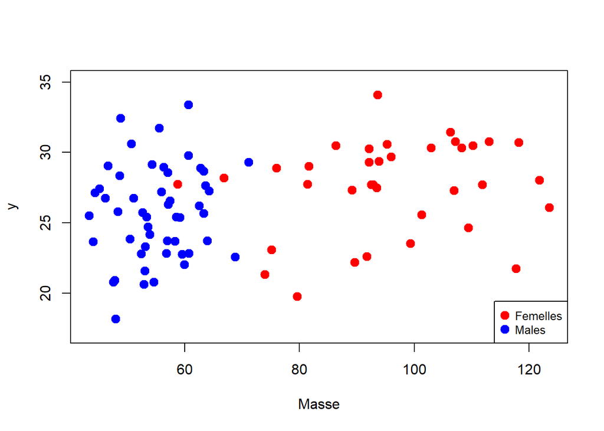

Les femelles sont nettement plus lourdes que les mâles ! Pas d’intéraction sexe x masse sur la température moyenne du corps pendant le vol.

#### — y ~ sexe*FMR

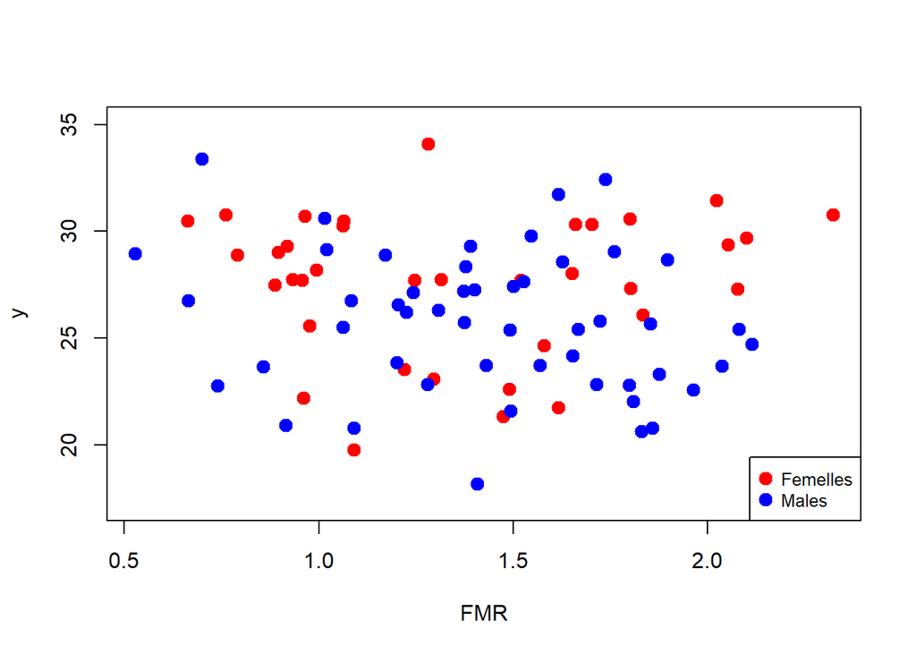

Pas d’interaction visible sexe*FMR sur la température.

#### — y ~ sexe*flight_duration

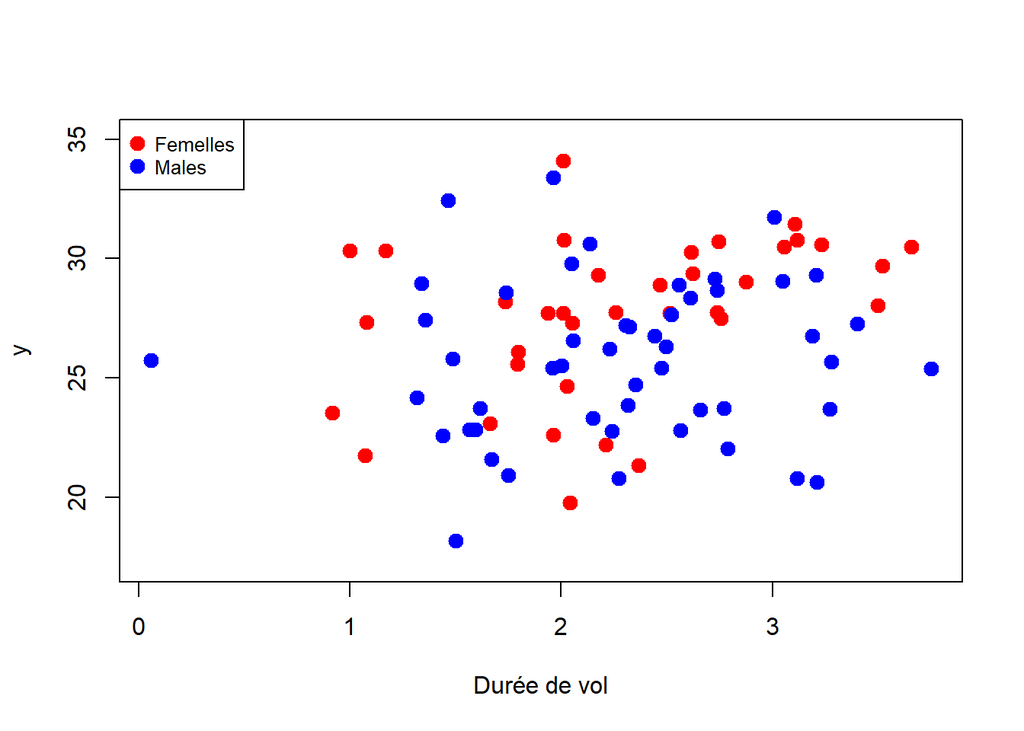

Pas d’interaction visible sexe*durée du vol sur la température.

#### — y ~ sexe*température au décollage

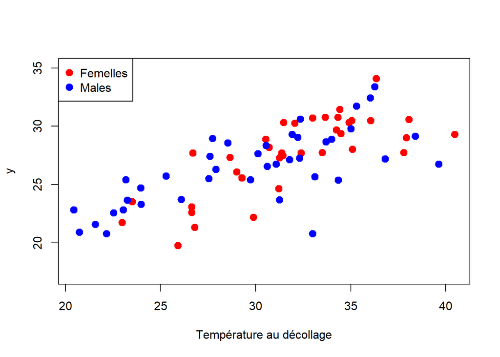

Pas d’interaction sexe*température au décollage sur la température pendant le vol.

#### — y ~ sexe*SNP331

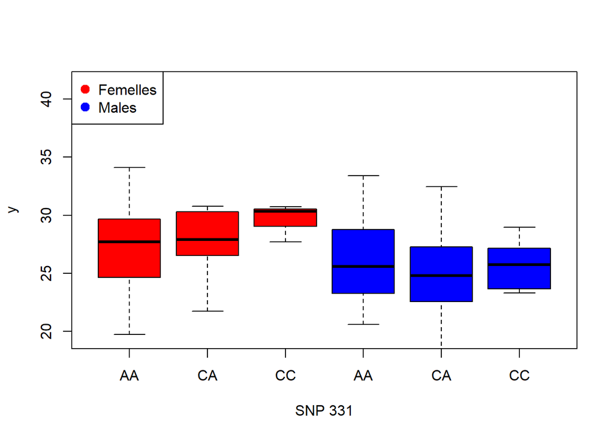

#### — y ~ sexe*SNP105

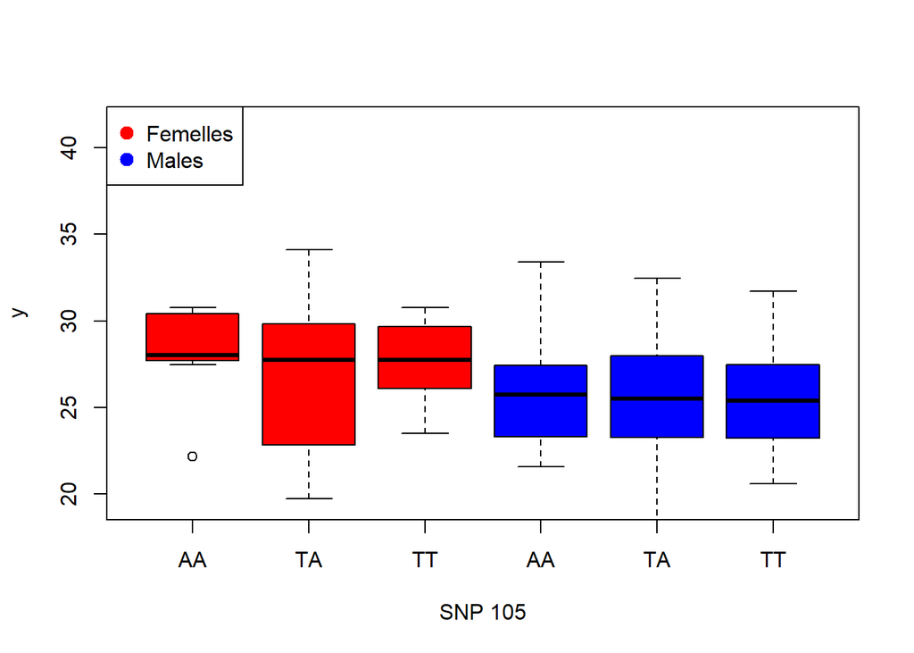

#### — y ~ sexe*SNP1083

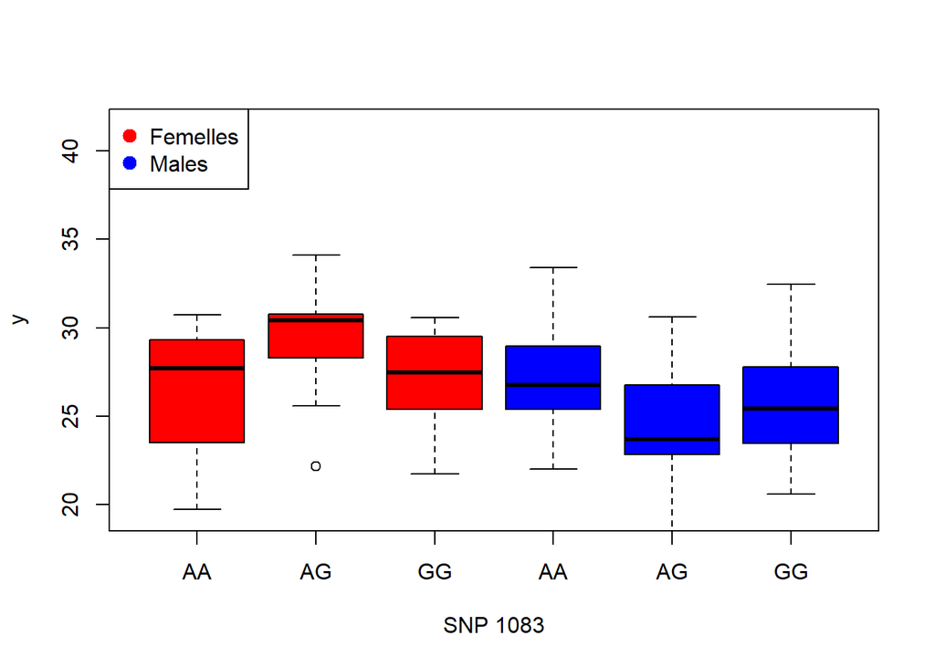

Aucune interaction claire entre le sexe et les variables génétiques.

# COLINEARITE ———————————————-

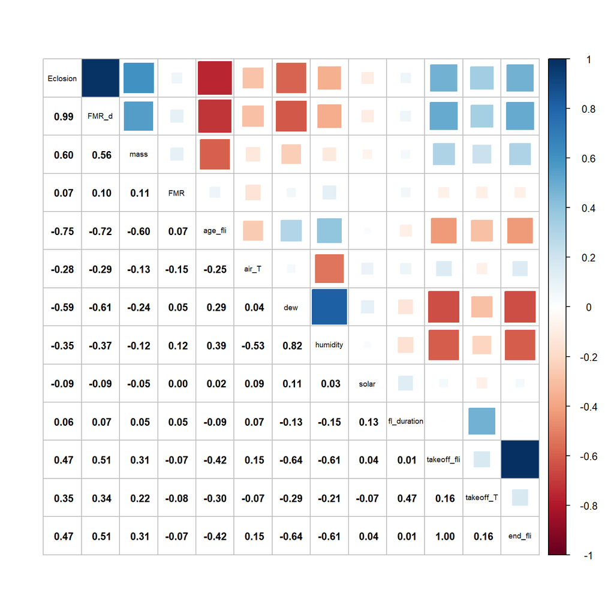

#### — Suppression des variables corrélées

```r
data <- data[!colnames(data) %in% c("eclosion_day", "flight_day", "age_flight", "dew_flight", "stop_flight", "end_flight_time")]

# On renomme le nom des lignes
rownames(data) <- 1:nrow(data)
```

# MODELISATION ———————————————-

### A. Sans effets aléatoires

On commence par le modèle “complet” en intégrant toutes les variables interprétables.

```r
mod <- lm(formula = mean_T_flight ~  FMR_day + age_FMR + FMR + sun_flight + air_T + humidity_flight + solar_radiation_flight + flight_duration + disturbed_flight + takeoff_T_thorax + (takeoff_time + mass + Pgi_105 + Pgi_1083 + Pgi_331)*sex,
      data = data)
```

#### — Multicolinéarité avec test VIF

On choisit un seuil entre >=5 pour le score VIF.

**Par itération**

```r
coli <- vif(mod, type = 'predictor')  # on supprime la variable wind_flight
coli[coli$GVIF == max(coli$GVIF),]["GVIF"]  # identification du plus grand vif
```

```
##             GVIF
## Pgi_105 12300.89
```

On supprime la variable ‘Pgi_105’

```
##              GVIF
## Pgi_1083 2559.906
```

On supprime la variable ‘Pgi_1083’

```
##                  GVIF
## takeoff_time 699.6446
```

```
##                 GVIF
## takeoff_time 499.212
```

```
##                  GVIF
## takeoff_time 14.85908
## sex          14.85908
```

On supprime la variable ‘takeoff_time’

```
##             GVIF
## FMR_day 4.138806
```

**La colinéarité a été contrôlée !**

#### — Selection du meilleur modèle

On sélectionne le meilleur modèle avec une procédure backward / forward baséé sur le critère de l’AIC.

```r
# On extrait la formule du modèle final
initial_formula <- formula(mod)

# Création modèle initial
initial_model <- lm(initial_formula, data = data)

# Utiliser step() pour sélectionner les termes du modèle
final_model <- step(initial_model, direction = "both", trace = FALSE, k = 3)

# Résultats
summary(final_model)
```

[output not shown]

```r
Anova(final_model, type = "III")
```

```
## Anova Table (Type III tests)
##
## Response: mean_T_flight
##                  Sum Sq Df  F value    Pr(>F)
## (Intercept)        0.06  1   0.0191  0.890356
## air_T            118.38  1  38.5266 3.221e-08 ***
## flight_duration   55.70  1  18.1280 6.222e-05 ***
## disturbed_flight  30.04  1   9.7754  0.002563 **
## takeoff_T_thorax 407.32  1 132.5566 < 2.2e-16 ***
## Residuals        218.17 71
## ---
## Signif. codes:  0 '***' 0.001 '**' 0.01 '*' 0.05 '.' 0.1 ' ' 1
```

Tous les prédicteurs sont significatifs, c’est notre modèle candidat.  
NOTE : on utilise une ANOVA de type III car la distribution des effectifs des modalités de la variable catégorielle ‘disturbed_flight’ est inégale.

```r
mod_candidat <- final_model
```

Le **modèle candidat final** est donc le modèle ci-dessus. Avant de l’interpréter on évalue la qualité du modèle.

#### — Evaluations des résidus

**Normalité, homogénéité des variance et contributions aberrantes (Cooks)**

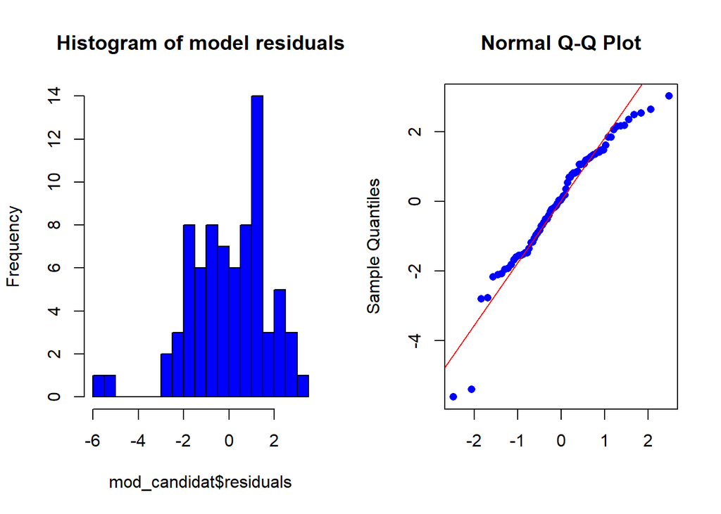

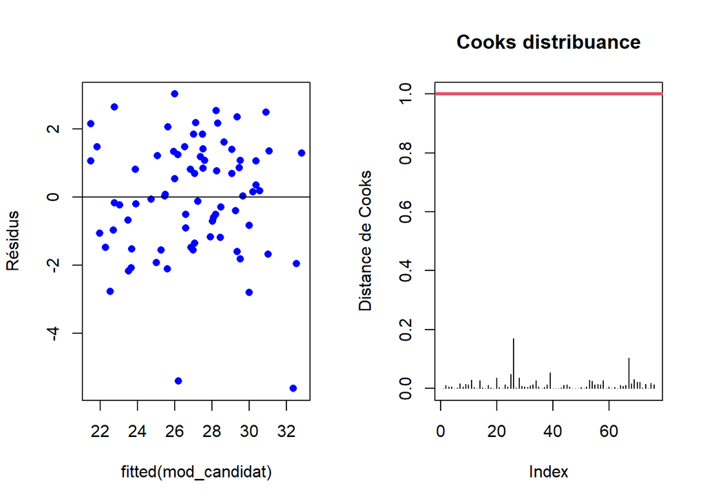

Deux points semblent se démarquer dans les résidus. On identifie leur ligne :

```r
outliers <- as.numeric(names(which(mod_candidat$residuals < -4)))
outliers
```

```
## [1] 36 77
```

On cherche à quelles variables sont associés les outliers en représantant y ~ chaque variable prédictive avec :

- rond plein : disturbed == YES
- rond vide : disturbed == NO

Les outliers sont représentés en rouges.

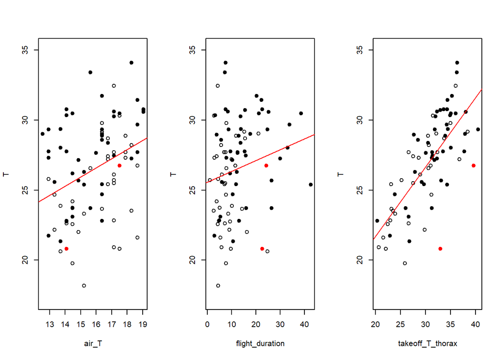

Nous n’avons pas réussi à identifier la source de cette variance élevée dans la prédiction de ces deux points. Le graphique de Cooks ne montre cependant pas de contribution trop aberrante, nous considérons que le modèle est interprétable même avec ces deux observations.  
On interprète le modèle :

#### — Pouvoir explicatif de chaque variable prédictive

Pour rendre compte de la contribution de chaque variable, nous avons calculé le ratio entre la contribution de chaque variable relativement à la variance totale :

```r
ano_mod <- Anova(mod_candidat, type = "III")
var_expliquee <- round(ano_mod$`Sum Sq`/ sum(ano_mod$`Sum Sq`), 3)  # Ratio de variance expliquée par variable
```

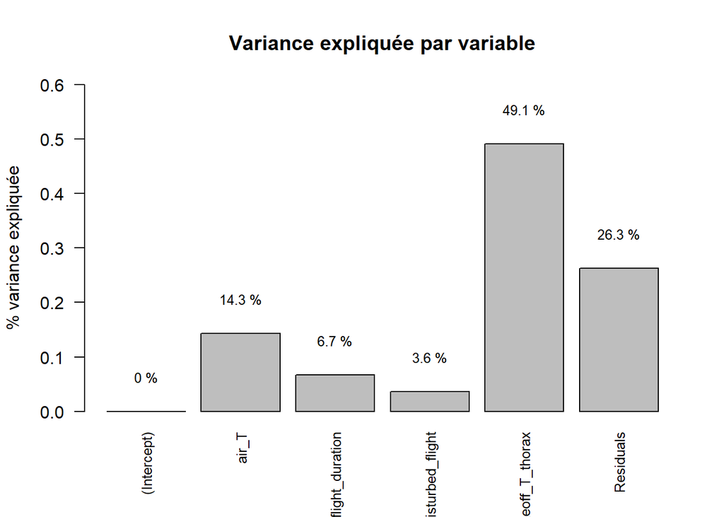

### B. Avec effets aléatoires

On réalise un modèle mixte avec la variable FMR_day (jour de mesure du FMR) comme effet aléatoire.

```r
mod <- lmer(formula = mean_T_flight ~  + (1|FMR_day) + age_FMR + FMR + sun_flight + air_T + humidity_flight + solar_radiation_flight + flight_duration + disturbed_flight + takeoff_T_thorax + (takeoff_time + mass + Pgi_105 + Pgi_1083 + Pgi_331)*sex,
      data = data)
```

```
## boundary (singular) fit: see help('isSingular')
```

On obtient un message d’erreur : (singular) fit: see help(‘isSingular’) indiquant une multicolinéarité.

#### — Multicollinéarité avec test VIF

On choisit un seuil entre >=5 pour le score VIF.

**Par itération**

```r
coli <- vif(mod, type = 'predictor')
coli[,1][coli[,1] == max(coli[,1])]   # identification du plus grand vif
```

```
##      sex
## 317.0245
```

On supprime la variable ‘Sex’

```
## sun_flight
##   11.06538
```

On supprime la variable ‘sun_flight’

```
##  Pgi_105
## 4.121382
```

Plus de colinéarité dans les effets fixes. On teste la colinéarité de l’effet principal en l’intégrant comme effet fixe :

```
##             GVIF
## FMR_day 5.150741
```

L’effet aléatoire est multicolinéaire (d’où l’erreur “matrice singulière”). Il n’est pas intégrable dans le modèle, on revient donc à notre modèle initial à effets fixes.

# CROSS VALIDATION DU MODELE ———————————————-

On cherche à valider le pouvoir prédictif du modèle candidat avec la méthode de la validation croisée en K-fold.

L’intérêt est de générer deux sous tableaux de données de tailles différentes : ‘Entraînement’ pour générer le modèle à partir ce ces données, et ‘Test’ afin de tester la précision du modèle. Ce processus est effectué K fois et à chaque fois, un score de précision est calculé. Le nombre K est choisi en fonction de la taille du dataset. Par défaut, on choisit K = 10.

Le résultat est une valeur de précision du modèle retenu (R²), les coefficients de chaque variable et l’erreur associée (RMSE et MAE).

La cross validation est possible grâce aux fonction ‘trainControl’ et ‘train’ du package ‘caret’.

```r
set.seed(100)
k <- 10 # Valeur par defaut souvent utilisee

# Définir le contrôle de la validation croisée avec preProcess
ctrl <- trainControl(method = "cv", number = k)
# Method = cross validation
# number = nombre de plis
# Mettre l'argument "MedianImpute" permet de combler les NAs

# Entraîner le modèle avec train()
model <- train(mean_T_flight ~ air_T + flight_duration + disturbed_flight + takeoff_T_thorax, data = data,
               method = "glm", trControl = ctrl, na.action = na.omit)

# Les NAs sont omis pour avoir le meme modele qu'initialement
# Cependant, il est possible d'utiliser l'argument 'MedianImpute' dans la fonction trainControl pour générer des valeurs pour les NAs

print(model)
```

```
## Generalized Linear Model
##
## 86 samples
##  4 predictor
##
## No pre-processing
## Resampling: Cross-Validated (10 fold)
## Summary of sample sizes: 69, 68, 68, 68, 68, 69, ...
## Resampling results:
##
##   RMSE      Rsquared   MAE
##   1.718448  0.7845366  1.452031
```

On obtient une précision de R² = 0.78 pour le modèle candidat.

### Modele final

```r
model$finalModel
```

```
##
## Call:  NULL
##
## Coefficients:
##         (Intercept)                air_T      flight_duration
##              0.3215               0.7292              -1.4863
## disturbed_flightYES     takeoff_T_thorax
##              1.5275               0.5675
##
## Degrees of Freedom: 75 Total (i.e. Null);  71 Residual
## Null Deviance:       809.8
## Residual Deviance: 218.2     AIC: 307.8
```

Le modele retenu par la validation croisee est mean_T_flight = 0.32 + 0.73 * air_T - 1.49 * flight_duration + 1.53 * disturbed_flight[==YES]+ 0.57 * takeoff_T_thorax

Avec 75 ddl, 71 residus.

Les predictions pour chaque pli :

```r
model$resample
```

```
##        RMSE  Rsquared       MAE Resample
## 1  2.546869 0.6689984 1.9136979   Fold01
## 2  1.519689 0.8552486 1.2462630   Fold02
## 3  1.874224 0.7616577 1.5771322   Fold03
## 4  2.842439 0.5726799 2.3430511   Fold04
## 5  1.643018 0.7149571 1.4237030   Fold05
## 6  1.416282 0.8999595 1.2919825   Fold06
## 7  1.317164 0.8747774 1.1593396   Fold07
## 8  0.944539 0.9163987 0.7925032   Fold08
## 9  1.690710 0.7552882 1.5108472   Fold09
## 10 1.389546 0.8254001 1.2617895   Fold10
```